# Intro_R_ECONS

## UFJF|FACULDADE DE ECONOMIA|ECONS

[figure not shown]

## LABORATÓRIO DE ESTUDOS ECONÔMICOS

## Introdução ao R

Stephanie M.P. da Costa; André Suriane

# Sumário

- 1 Introdução
- 2 Instalando o R
  - 2.1 Interface do R
- 3 Comandos Básicos
  - 3.1 Utilizando Ajuda
  - 3.2 Instalando Pacotes
  - 3.3 Atribuição de Valores
  - 3.4 Comandos Auxiliares
  - 3.5 Operações matemáticas simples
  - 3.6 Operações lógicas simples
  - 3.7 Funções matemáticas simples
- 4 Operações básicas no R
  - 4.1 Vetores
  - 4.2 Arrays
  - 4.3 Matrizes
  - 4.4 Listas
  - 4.5 Data frames
- 5 Importação de dados
  - 5.1 Importando arquivos .csv
  - 5.2 salvando e abrindo data frame
- 6 Gráficos

# 1 Introdução

O objetivo do curso R-Econs é apresentar aos alunos de graduação e pós-graduação uma maneira simples e eficaz de manipular dados através da linguagem de programação R. O objetivo deste curso é capacitar o usuário a visualizar e manipular dados e microdados no R a partir da compreensão da estrutura e funcionamento do software. Para isso são apresentados a operacionalização do R e algumas funções básicas, como manipular bancos de dados, melhorar a "aparência" dos dados, modificar e criar variáveis e calcular algumas estatísticas descritivas, criar apresentações gráficas dos dados.

# 2 Instalando o R

O R é um software livre para computação estatística e construção de gráficos que pode ser baixado e distribuído gratuitamente de acordo com a licença GNU. O R está disponível para as plataformas UNIX, Windows e MacOS.

### Windows - Instalação rápida

- baixe o aplicativo no link, e execute seguindo as observações para instalação.

http://cran-r.c3sl.ufpr.br/bin/windows/base/

- Observação: pode haver versões novas.

##### Interface R no sistema operacional Windows

[figure not shown]

### Linux - distribuição Ubuntu

- Execute em um terminal

Ubuntu

> `sudo apt-get install r-base r-base-core`

Fedora/RHEL/CENTOS

> `sudo yum install R`

Obs: Entre em http://cran-r.c3sl.ufpr.br/bin/linux e veja as instruções específicas para sua distribuição. As distribuições que já possuem pacotes pré-compilados são: Debian, RedHat (CentOS), Fedora, Suse (OpenSuse).

##### Interface R no sistema operacional Linux - Ubuntu

[figure not shown]

## 2.1 Interface do R

Fazer dowload no link: https://www.rstudio.com/products/rstudio/download/

Escolher a ultima versão do RStudio para instalar, lembrando sempre que pode haver versões novas.

##### Interface do RStudio

[figure not shown]

# 3 Comandos Básicos

## 3.1 Utilizando Ajuda

O R conta com o comando `help()` para consultar a sintaxe de algum comando ou obter mais informações sobre determinada função. (Podemos usar também o painel do RStudio).

*Exemplo:*

```r
help(comando) # sintaxe
help(sqrt)
help("sqrt")
?sqrt
help.search("sqrt")
```

Ao executar o exemplo acima no R, uma interface do menu de ajuda será executada mostrando o tópico da função sqrt, que é função matemática para a raiz quadrada.

*Exemplo da descrição de ajuda para a função sqrt.*

[figure not shown]

- Para conhecer e tirar dúvidas sobre o R acesse:

> https://cran.r-project.org/manuals.html

> https://cran.r-project.org/

## 3.2 Instalando Pacotes

O R conta com uma infinidade de pacotes permitindo o usuário as mais diversificadas ações. Para installar um pacote use `install.packages("pkg.name")` ou use o painel do RStudio (Packages/Install).

*Exemplo:*

`install.packages("ggplot2")`

## 3.3 Atribuição de Valores

Como todo tipo de programação, é comum que tenhamos que atribuir valores para algumas variáveis antes de utilizá-las. No R podemos fazer uma atribuição de valores de várias formas, conforme os exemplos abaixo:

```r
x <- 5 # x recebe o valor 5
x = 19 # x recebe o valor 19
assign ("x", 2i) # x recebe o numero imaginario 2i
```

Apesar das diferentes formas de atribuição mostradas acima. Utilizaremos nessa apostila, por uma questão de precedência de operadores, sempre os símbolos `<-` para atribuição de valores.

Para mostrar o valor armazenado em uma variável, basta digitar a variável no Console e apertar Enter. Qualquer valor digitado sem atribuição pode ser mostrado na tela.

```r
x <- 50
x/20
```

2.5

```r
x  = 10:20
x[1:5]
```

1. 10

2. 11

3. 12

4. 13

5. 14

```r
y <- sum((10:20)^2)==sum(x^2)
 y
```

TRUE

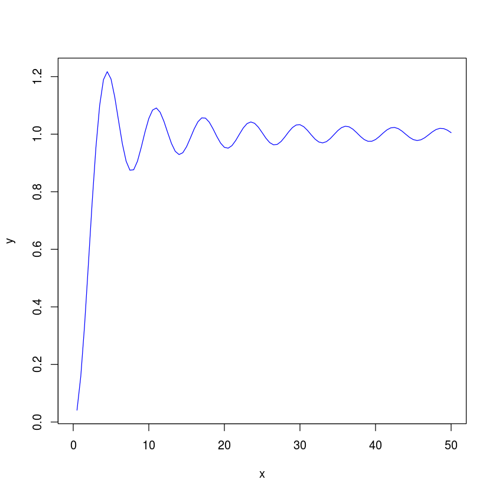

```r
x <- seq(0, 50, l = 101)
y <- 1 - (1/x) * sin(x)
plot(x,y,  type = "l", col = "blue")
```

## 3.4 Comandos Auxiliares

Abaixo veremos uma tabela com os principais comandos que ajudam a manipular os objetos e a "workspace" que estão sendo utilizados durante a execução do programa.

- `install.packages() # Instalar pacotes`
- `library() # Loads packages`
- `c() list() # Construir vetor; Listar vetor`
- `data.frame() # Construir data.frames`
- `x:y # Criar vetor entre valores x:y`
- `range() # Retornar o min/max de valores do vetor`
- `sum() # Calcular soma`
- `mean() # Calcular a media`
- `prod() # Calcular o produto`
- `cor() # Calcular a correlacao entre duas variáveis`
- `getwd() # Mostrar o diretorio atual`
- `setwd() # Definir o diretorio de trabalho`
- `dir() # Listar os arquivos no diretorio de trabalho`
- `? # Buscar ajuda`
- `read.table() read.csv() read.delim() # Importar dados`
- `colnames() # Informar ou aplicar nomes em vetores`
- `head() tail() # Informar primeiro é ultimo dado em um data.frame`
- `summary() aggregate() table(x) addmargins(table(x)) prop.table(table(x), 1:2) # Estimar tabelas estatisticas`
- `x<y; x>y; x<=y; x>=y; x==y; x!=y; x%in%Y # Operadores relacionais`
- `x+y; x-y; x*y; x/y; x^y OR x**y; x%%y; x%/%y (integer division) # Operadores aritmeticos`
- `! & | xor() && || # Operadores logicos`
- `x[i] (for 1-dimensional vectors) x[i, j] (x$j (only for data.frames)) # Extrair ou aplicar elemento em arrays`
- `plot(y ~ x) hist(y) boxplot(y ~ x) # Gerar graficos`

  *Exemplos:*

```r
#setwd("~/Rcurso")
getwd()
x <- seq(0, 50, l = 101)
y <- 1 - (1/x) * sin(x)
mean(x)
mean(y)
mean(y, na.rm=TRUE)
```

'/mnt/Disco1/Jupyter/Rcurso'

25

NaN

0.973985776746886

```r
# remover Na NaN
mean(na.omit(y))
sum(y, na.rm = TRUE)
cor(x[2:50], y[2:50])
```

0.973985776746886

97.3985776746886

0.411679957637109

## 3.5 Operações matemáticas simples

As operações matemáticas simples que podem ser executadas no R são:

- potenciação (^);
- divisão (/);
- divisão inteira ( % / %) - retorna o quociente inteiro da divisão;
- divisão resto (%%); - retorna o resto da divis~ao
- multiplicação (∗);
- adição (+);
- subtração (-)

  **Exemplo:**

```r
x <- 3;
2*(1 >(3&(4 <=x)*!0));
```

2

```r
20 / 3
20 %/% 3  # retorna o quociente inteiro da divisao
20 %% 3  # retorna o resto da divisao
```

6.66666666666667

6

2

## 3.6 Operações lógicas simples

- diferente (!);
- não (!x);
- e (&) # operacao elemento a elemento;
- ou (|) # operacao elemento a elemento;
- ou exclusivo (xor(x,y));
- verificando vetor unitário (isTrue(x));
- e (&&) # operacao com apenas o primeiro elemento de um vetor;
- ou (||) # operacao com apenas o primeiro elemento de um vetor. *Exemplo:*

```r
c(1!=2, 1!=1, 1&2<=1, 1&2>0, 1|2!=1 ,1|2==1)
```

1. TRUE

2. FALSE

3. FALSE

4. TRUE

5. TRUE

6. TRUE

## 3.7 Funções matemáticas simples

Algumas chamadas de funções matemáticas simples.

- abs(x) # valor absoluto
- log(x,b) # logaritmo de x com base b
- log(x) # logaritmo natural de x
- log10(x) # logaritmo de x com base 10
- exp(x) # exponencial elevado a x
- sin(x) # seno de x
- cos(x) # cosseno de x
- tan(x) # tangente de x
- round(x, digits = n) # arredonda x com n decimais
- ceiling(x) # arredondamento de x para o maior valor
- floor(x) # arredondamento de x para o menor valor
- length(x) # numero de elementos do vetores
- sum(x) # soma dos elementos do vetor x
- prod(x) # produto dos elementos do vetor x
- max(x) # seleciona o maior elemento do vetor x
- min(x) # seleciona o menor elemento do vetor x
- range(x) # retorna o menor e o maior elemento do vetor x

# 4 Operações básicas no R

O R é orientado a objetos. Os tipos básicos de objetos são: vetores, matrizes, dataframes, listas e funcões. Nessa seção aprenderemos um pouco mais sobre essas estruturas de dados e alguns comandos básicos para manipulá-las.

## 4.1 Vetores

Vetores são uma sequências de valores numéricos ou de caracteres(letras, palavras). Sua principal utilidade é poder armazenar diversos dados em forma de lista e aplicar funções e operações sobre todos os dados pertencentes a determinado vetor com apenas poucos comandos.

*Exemplo:*

```r
vec <-c(1,4,10,13.10,91,15.8) #forma mais simples de declarar um vetor
  vec2 <- (1:6) # cria um vetor de 1 ate 6
  vec3 <- c((1:3),(3:1))
  vec4 <- c(0,vec3[1:2], vec3[5:6] , 0)
   matrix(c(vec,vec2,vec3,vec4),6,4,0)
```

| 1.0 | 1 | 1 | 0 |
| --- | --- | --- | --- |
| 4.0 | 2 | 2 | 1 |
| 10.0 | 3 | 3 | 2 |
| 13.1 | 4 | 3 | 2 |
| 91.0 | 5 | 2 | 1 |
| 15.8 | 6 | 1 | 0 |

```r
seq(from = 1, to = 5) # vetor de 1 ate 5
  seq(from = 1 , to = 15, by = 2) #vetor de 1 ate 15 com passo 2
  seq(from = 1 ,to = 15, length.out = 2) #vetor de 1 ate 15 com 2 elementos
  rep(10, 10) # repete o elemento 10, dez vezes
  rep(3:6, 3) #repete a sequência de 3 a 6, três vezes
```

1. 1

2. 2

3. 3

4. 4

5. 5

1. 1

2. 3

3. 5

4. 7

5. 9

6. 11

7. 13

8. 15

1. 1

2. 15

1. 10

2. 10

3. 10

4. 10

5. 10

6. 10

7. 10

8. 10

9. 10

10. 10

1. 3

2. 4

3. 5

4. 6

5. 3

6. 4

7. 5

8. 6

9. 3

10. 4

11. 5

12. 6

## 4.2 Arrays

Podemos definir arrays como um conjunto de elementos de dados, geralmente do mesmo tamanho e tipo de dados. Elementos individuais são acessados por sua posição no array. A posição é dada por um índice, também chamado de subscrição. O índice geralmente utiliza uma sequência de números naturais. Arrays podem ser de qual- quer tipo, porém neste capítulo abordaremos apenas arrays numéricos, devido a sua grande importância para declaração de matrizes. Existem arrays unidimensionais e multi- dimensionais. Arrays numéricos unidimensionais nada mais são do que vetores, como já vimos. Já arrays numéricos multidimensionais podem ser usados para representação de matrizes.

*Exemplo:*

```r
# x <- array (dados, dim = vetor_dimensao) #sintaxe
x <- array(c(10:20), dim = c(2,5))
 x
```

| 10 | 12 | 14 | 16 | 18 |
| --- | --- | --- | --- | --- |
| 11 | 13 | 15 | 17 | 19 |

*Obs: Vetores são arrays de uma dimensão. Já Arrays podem ser definidos com quantas dimensões o usuário desejar.*

## 4.3 Matrizes

Matrizes são coleções de vetores em linhas e colunas, todos os vetores devem ser do mesmo tipo (numérico ou de caracteres).

```r
# x <-matrix(data = dados, nrow = m, ncol = n, byrow = Q) #sintaxe
# /* comentario  */
# "m" = numero de linhas, "n" = numero de colunas
# se Q = 1 #ativa disposicao por linhas
# se Q = 0, mantem disposicao por colunas
# /* comentario */
 M <- matrix(c(3:10), 2,4 )
 M
 M[1,3] # retorna o elemento que se encontra na linha 1 e coluna 3
 M[2,] # retorna todos os elementos da linha 2
```

| 3 | 5 | 7 | 9 |
| --- | --- | --- | --- |
| 4 | 6 | 8 | 10 |

7

1. 4

2. 6

3. 8

4. 10

##### Operações e funções matriciais

Abaixo segue uma tabela com as principais operações e funções realizadas entre matrizes.

- A * B # produto elemento a elemento de A e B
- A% * %B #produto matricial de A por B
- A = aperm (A) # matriz transposta A = A^{t}
- A = t(A) # matriz transposta A = A^{t}
- B = solve (B) #matriz inversa B = B^{-1}
- x = solve(A,b) #resolve o sistema linear Ax = b
- det (C) # retorna o determinante de C
- diag(v) # retorna uma matriz diagonal onde o vetor v é a diagonal
- diag(A) # retorna um vetor que é a diagonal d a matriz A
- diag(n) # sendo n um inteiro, retorna uma matriz identidade de ordem n
- eigen(A) # retorna os autovalores e autovetores de A
- eigen(A)\$values # retorna os autovalores de A
- eigen(A)\$vectors # retorna os autovetores de A

```r
A <- M%*%t(M)
B <- t(M)%*%M
C <- kronecker(t(M), M) # == kronecker(M, t(M))
D <- replicate(8,"_|_")
D<- data.frame(A,D,B,D,C)
colnames(D)<- c("A1", "A2", "T",  "B1", "B2","B3", "B4","T",  "C1", "C2","C3", "C4", "C5", "C6","C7", "C8" )

D[3:8,1:2] <- NA
D[5:8,4:7] <- NA
D
```

| A1 | A2 | T | B1 | B2 | B3 | B4 | T | C1 | C2 | C3 | C4 | C5 | C6 | C7 | C8 |
| --- | --- | --- | --- | --- | --- | --- | --- | --- | --- | --- | --- | --- | --- | --- | --- |
| 164 | 188 | _\|_ | 25 | 39 | 53 | 67 | _\|_ | 9 | 15 | 21 | 27 | 12 | 20 | 28 | 36 |
| 188 | 216 | _\|_ | 39 | 61 | 83 | 105 | _\|_ | 12 | 18 | 24 | 30 | 16 | 24 | 32 | 40 |
| NA | NA | _\|_ | 53 | 83 | 113 | 143 | _\|_ | 15 | 25 | 35 | 45 | 18 | 30 | 42 | 54 |
| NA | NA | _\|_ | 67 | 105 | 143 | 181 | _\|_ | 20 | 30 | 40 | 50 | 24 | 36 | 48 | 60 |
| NA | NA | _\|_ | NA | NA | NA | NA | _\|_ | 21 | 35 | 49 | 63 | 24 | 40 | 56 | 72 |
| NA | NA | _\|_ | NA | NA | NA | NA | _\|_ | 28 | 42 | 56 | 70 | 32 | 48 | 64 | 80 |
| NA | NA | _\|_ | NA | NA | NA | NA | _\|_ | 27 | 45 | 63 | 81 | 30 | 50 | 70 | 90 |
| NA | NA | _\|_ | NA | NA | NA | NA | _\|_ | 36 | 54 | 72 | 90 | 40 | 60 | 80 | 100 |

*Resolver o sistema de equações:*

- x + y =0
- y + 4z =1
- y + 2z =5

```r
b <- array(c(0,1,5), dim = c(3,1))
C <- matrix(c(c(1,1,0),c(0,1,4),c(0:2)),3,3,1)
R = solve(C,b)
c("x","y","z", "=", R)
```

1. 'x'

2. 'y'

3. 'z'

4. '='

5. '-9'

6. '9'

7. '-2'

- rowSums(a) - Soma de elementos das linhas da matriz
- colSums(a) - Soma de elementos das colunas da matriz
- rowMeans(a) - média das linhas
- colMeans(a) - média das colunas

```r
colMeans(A)
colSums(B)
rowSums(C)
rowMeans(B)
```

1. 176

2. 202

1. 184

2. 288

3. 392

4. 496

1. 2

2. 5

3. 3

1. 46

2. 72

3. 98

4. 124

## 4.4 Listas

Listas são conjuntos de vetores, data frames ou de matrizes. Não precisam ter o mesmo tamanho.

## 4.5 Data frames

Data frames também são coleções de vetores, mas aceitam vetores de tipos diferentes (numéricos e caracteres). Normalmente, guardamos dados em objetos do tipo data frame, pois sempre temos variáveis numéricas e variáveis categóricas, por exemplo, nome do aluno e idade do aluno, respectivamente. Desse modo, essa estrutura proporciona mais liberdade para manipulação de dados.

Com a função data.frame reunimos vetores de mesmo comprimento em um só objeto:

`dataframe <- data.frame() #sintaxe`

*Exemplo:*

```r
df <- data.frame (ipca = c(6.62, 4.61,6.03,5.28, 5.70),
                selic = c(1.46, 1.15, 1.16, 1.21, 1.24))
df[1:2,]
```

| ipca | selic |
| --- | --- |
| 6.62 | 1.46 |
| 4.61 | 1.15 |

Transformando outros objetos em um data.frame com a função as.data.frame()

```r
ipca <-c(6.62,4.61,6.03,5.28, 5.70)
selic <- c(1.46,1.15,1.16,1.21,1.24)
nivel_emprego <- c(159.1473,158.0703,156.1412,152.7011,150.9488)
df2 <-data.frame (ipca ,selic , nivel_emprego )
df2[1:3,]
```

| ipca | selic | nivel_emprego |
| --- | --- | --- |
| 6.62 | 1.46 | 159.1473 |
| 4.61 | 1.15 | 158.0703 |
| 6.03 | 1.16 | 156.1412 |

O data.frame sempre terá rownames e colnames.

```r
rownames(df2)
colnames(df2)<- c("ipca" , "selic", "ne")
colnames(df2)
```

1. '1'

2. '2'

3. '3'

4. '4'

5. '5'

1. 'ipca'

2. 'selic'

3. 'ne'

#### Ordenado data.frame

```r
newdf <-df2[ order ( selic ) ,] # ordenando todo o data.frame segundo a variavel selic em ordem crescente
newdf
```

|  | ipca | selic | ne |
| --- | --- | --- | --- |
| 2 | 4.61 | 1.15 | 158.0703 |
| 3 | 6.03 | 1.16 | 156.1412 |
| 4 | 5.28 | 1.21 | 152.7011 |
| 5 | 5.70 | 1.24 | 150.9488 |
| 1 | 6.62 | 1.46 | 159.1473 |

```r
newdf2 <-df2[ order (ipca ,selic ),]
newdf2
```

|  | ipca | selic | ne |
| --- | --- | --- | --- |
| 2 | 4.61 | 1.15 | 158.0703 |
| 4 | 5.28 | 1.21 | 152.7011 |
| 5 | 5.70 | 1.24 | 150.9488 |
| 3 | 6.03 | 1.16 | 156.1412 |
| 1 | 6.62 | 1.46 | 159.1473 |

```r
df2[ order (-ipca , selic ) ,]
```

|  | ipca | selic | ne |
| --- | --- | --- | --- |
| 1 | 6.62 | 1.46 | 159.1473 |
| 3 | 6.03 | 1.16 | 156.1412 |
| 5 | 5.70 | 1.24 | 150.9488 |
| 4 | 5.28 | 1.21 | 152.7011 |
| 2 | 4.61 | 1.15 | 158.0703 |

Para remoção de uma coluna no dataframe basta atribuir NULL a coluna desejada.

*Exemplo:*

```r
df$ipca <-NULL
df
```

| selic |
| --- |
| 1.46 |
| 1.15 |
| 1.16 |
| 1.21 |
| 1.24 |

Outras funções:

- names () # retorna os nomes das colunas
- with () # permite operacoes nas colunas sem repetir o nome do data.frame seguido de "$" , [ , ] ou [[]].
- sapply ()# aplica uma determinada funcao nas colunas de um data.frame
- lapply () # aplica uma determinada funcao nas colunas de um data.frame , retornando uma lista
- filter () # permite filtrar apenas colunas de uma determinada classe ou referente a alguma condicao
- attach () # anexa ao conjunto de dados , de modo a poder chamar colunas diretamente
- cumsum () # a soma cumulativa de todas as entradas tomadas coluna a coluna .
- cumprod () # o produro cumulativo de todas as entradas tomadas coluna a coluna
- cummin () # retorna um vetor onde o n- esimo elemento eh o minimo de x[1] ate x[i]
- cummax () # retorna um vetor onde o n- esimo elemento eh o maximo de x[1] ate x[i]
- saveRDS() # salvar um data.frame comprimindo os dados (pode levar tempo no caso de grandes bases)

```r
system.time({
  saveRDS(df2, "Exdf2")
})
```

```
   user  system elapsed
      0       0       0
```

# 5 Importação de dados

Se os dados estiverem salvos em arquivos, sob forma de planilhas, tabelas, etc., deve- se fazer com que o R leia estes arquivos, transformando-os em um objeto. Para que o R reconheça o conjunto de dados do arquivo é necessário que as colunas sejam separadas. Caso isso não ocorra o R não conseguirá separar as colunas e emitirá uma mensagem de erro. Um modo fácil de resolver este problema é salvar a planilha de dados com o formato (.csv) que utiliza virgula (,) como elemento separador das colunas. Porém, antes de iniciar a entrada de dados no R deve-se alterar a pasta de trabalho padrão em que o arquivo de dados .csv será salvo. Para isso basta ir em :Arquivo/Mudar dir... e alterar o diretório em que será salvo o arquivo. Ao abrir a página de alteração do diretório, escolha o diretório em que será salvo o arquivo. Depois de salvar o arquivo no diretório especificado, carregue o arquivo no console do R.

Outra maneira de alterar o diretório é utilizar o seguinte comando, especificando, como argumento, o diretório requerido:

`setwd('Rdados') # ou C:\Rdados`

Conferindo o diretório atualizado através do comando:

`getwd ()`

## 5.1 Importando arquivos .csv

De posse da pasta de trabalho e do arquivo no formato .csv na pasta Rdados, procederemos com o seguinte comando:

`dir ()`

Com este comando o R irá verificar se há algum arquivo na pasta de trabalho. Como previamente havíamos salvo um arquivo .csv, sabemos que o R irá encontrar este arquivo no diretório especificado anteriormente.

```r
datacsv <- read.csv2("Exemplo/Exemplo1_ipca.csv",header =T, sep=";", dec=".")
#
#datacsv <- read.table("~/Jupyter/Rcurso/Exemplo/Exemplo1_ipca.csv",header =T, sep=";" ,dec=",")
```

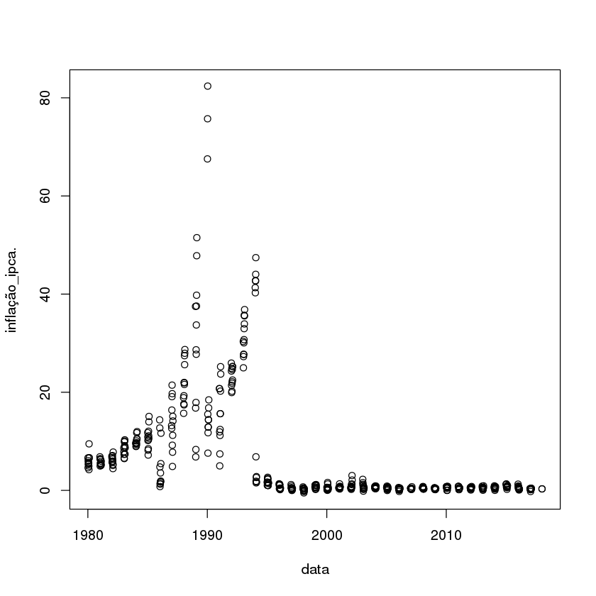

```r
plot(datacsv)
```

**Sendo:**

- datacsv: é o objeto no qual os dados lidos serão reconhecidos pelo R;
- read.csv2 : função que lê o arquivo do tipo.csv.
- read.table: função que também lê arquivos do tipo.csv, mas organiza os dados em formato de tabela.

**Observação:**

existem outras sintaxes para carregar dados no console do R (verifique isso utilizando o comando “help(read.table)”), porém os argumentos permanecem idênticos aos apresentados anteriormente.

Caso o arquivo tenha título, podemos verificar o nome destes títulos através do comando:

`names() # no argumento vai sempre o nome do objeto desejado`

Podemos ver a dimensão do arquivo carregado por meio do seguinte comando:

`dim()`

`head () # retorna a primeira parte de um vetor , matriz , tabela , data frame ou funcao.'

```r
names(datacsv);
dim(datacsv);
head( datacsv , 5) # igual datacsv[1:5 ,]
```

1. 'data'

2. 'inflação_ipca.'

1. 458

2. 2

| data | inflação_ipca. |
| --- | --- |
| 1980.01 | 6.62 |
| 1980.02 | 4.62 |
| 1980.03 | 6.04 |
| 1980.04 | 5.29 |
| 1980.05 | 5.70 |

Isto porque o R, agora, considera o arquivo carregado como uma matriz ou data.frame. Desta forma, podemos localizar linhas, colunas e elementos desta matriz. Para isso, utilize os comandos abaixo: `datacsv[1:5,]` , `datacsv[1,1]`.

Para desenvolver um exemplo com um arquivo .txt seguimos os seguintes passos:

dir() # verifica a presenca de arquivos no diretorio de trabalho

```r
dir('Exemplo')
```

1. 'arquivoteste.txt'

2. 'dados.csv'

3. 'dados2.txt'

4. 'dados3.csv'

5. 'Exemplo1_ipca.csv'

6. 'Exemplo1_ipca.xls'

7. 'exemplo1.csv'

8. 'Exemplo1.xls'

9. 'Exemplo2_ipeadata[02-04-2018-05-08] (1).xls'

10. 'Exemplo2_selic.csv'

11. 'exemplo2.csv'

12. 'Exemplo2.xls'

13. 'Exemplo3_ipeadata[02-04-2018-05-09].xls'

14. 'Exemplo3_nivelemprego.csv'

15. 'exemplo3.csv'

16. 'Exemplo3.xls'

17. 'histograma.png'

18. 'ipca_2000_2001'

19. 'ipca.png'

20. 'ipca2.csv'

21. 'ipca3.csv'

22. 'nivelemprego2.csv'

23. 'nivelemprego3.csv'

24. 'plot.png'

25. 'plot2.png'

26. 'return'

27. 'selic2.csv'

28. 'selic3.csv'

29. 'teste.png'

30. 'USAR NO MINICURSO'

```r
datatxt <- read.table('Exemplo/arquivoteste.txt',header=T, sep = ",", dec=".")
 datatxt[1:3,]
```

| DATA | Inflação_IPCA | SELIC | DESEMPREGO |
| --- | --- | --- | --- |
| 1980.01 | 6.615649 | 1.46 | 159.1473 |
| 1980.02 | 4.616919 | 1.15 | 158.0703 |
| 1980.03 | 6.038389 | 1.16 | 156.1412 |

Podemos ainda carregar um arquivo de qualquer diretório basta apenas informar este diretório no comando. Para isso, basta utilizar a sintaxe abaixo:

`datatxt <- read.table('~/Jupyter/Rcurso/Exemplo/arquivoteste.txt',header=T, sep = ",", dec=".")`

```r
ipca <- read.csv2("Exemplo/Exemplo1_ipca.csv", header = T, sep = ";", dec = ".")
ipca <- subset(ipca, data >= 2000 & data <=2015   )
colnames(ipca) <- c("data", "ipca")
c(ipca[1:5,],datacsv[1:5,]   )
```

**$data**

1. 2000.01

2. 2000.02

3. 2000.03

4. 2000.04

5. 2000.05

**$ipca**

1. 0.62

2. 0.13

3. 0.22

4. 0.42

5. 0.01

**$data**

1. 1980.01

2. 1980.02

3. 1980.03

4. 1980.04

5. 1980.05

**$inflação_ipca.**

1. 6.62

2. 4.62

3. 6.04

4. 5.29

5. 5.7

```r
selic <- read.csv2 ("Exemplo/Exemplo2_selic.csv", header = T, sep = ",", dec = ".")
selic<- subset(selic, data >=2000 & data <=2015 )
nivel_emprego <- read.csv2 ("Exemplo/Exemplo3_nivelemprego.csv", header = T, sep = ";", dec = ".")
nivel_emprego <- subset(nivel_emprego, data >=2000 & data <=2015 )
dados <- data.frame (selic , ipca , nivel_emprego)
```

Salvando os dados em um arquivo.txt via `write.table()` e arquivo csv via a função `write.csv()`. contudo é possivel salvar um arquivo csv usando `write.table()` ou o contrário.

```r
write.table(dados, "Exemplo/dados.csv", sep = ";")
write.csv(dados, "Exemplo/dados.txt")
```

## 5.2 salvando e abrindo data frame

```r
x <- runif(1000000)
x[sample(1000000, 900000)] <- NA # 10% NAs
df3 <- as.data.frame(replicate(100, x))
a <- dim(df3)
```

```r
rs1 <- system.time({
    save(df3, file = "EXEsave.Rdata")
})
ro1 <- system.time({
    load("EXEsave.Rdata")
})

sa1<-file.size("EXEsave.Rdata")/(1024*1024)

rs2 <- system.time({
  saveRDS(df3, "EXEsave.RDS")
})
ro2 <- system.time({
    readRDS("EXEsave.RDS")
    })
sa2<-file.size("EXEsave.RDS")/(1024*1024)

rs3 <- system.time({
    write.csv(df3, 'EXEsave.csv')
   })
ro3 <- system.time({
    read.csv('EXEsave.csv')
   })
sa3<-file.size("EXEsave.csv")/(1024*1024)
```

```r
library("feather")

rs4 <- system.time({
    write_feather(df3, 'EXEsave.feather')
   })
ro4 <- system.time({
    read_feather('EXEsave.feather')
   })
sa4<-file.size("EXEsave.feather")/(1024*1024)

library("foreign")

rs5 <- system.time({
    write.dta(df3, 'EXEsave.dta')
   })
ro5 <- system.time({
    read.dta('EXEsave.dta')
   })
sa5<-file.size("EXEsave.dta")/(1024*1024)
```

```r
saved <- data.frame(matrix(c(
                    rs1, sa1 , a,
                    rs2, sa2 , a,
                    rs3, sa3 , a,
                    rs4, sa4 , a,
                    rs5, sa5 , a
                    ) ,5,8,1))

opend <- data.frame(matrix(c(
                    ro1, sa1 , a,
                    ro2, sa2 , a,
                    ro3, sa3 , a,
                    ro4, sa4 , a,
                    ro5, sa5 , a
                    ) ,5,8,1))
colnames(opend) <-c( "user" , "system", "elapsed", "user.child", "sys.child", "size", "N", "K")
rownames(opend) <- as.factor(c("Rdata", "RDS", "CSV", "Feather", "Stata"))
colnames(saved) <-c( "user" , "system", "elapsed", "user.child", "sys.child", "size", "N", "K")
rownames(saved) <-as.factor(c("Rdata", "RDS", "CSV", "Feather" ,"Stata"))

opend$user.child<-opend$sys.child<-NULL
saved$user.child<-saved$sys.child<-NULL

saved[order (saved$user),]
opend[ order (opend$user),]
```

|  | user | system | elapsed | size | N | K |
| --- | --- | --- | --- | --- | --- | --- |
| Feather | 0.956 | 0.540 | 3.945 | 774.86774 | 1e+06 | 100 |
| Stata | 4.996 | 0.828 | 6.927 | 762.95501 | 1e+06 | 100 |
| RDS | 15.880 | 0.093 | 15.975 | 74.00142 | 1e+06 | 100 |
| Rdata | 15.997 | 0.067 | 17.584 | 74.00145 | 1e+06 | 100 |
| CSV | 45.622 | 0.559 | 46.601 | 437.63522 | 1e+06 | 100 |

|  | user | system | elapsed | size | N | K |
| --- | --- | --- | --- | --- | --- | --- |
| Feather | 1.097 | 0.221 | 1.775 | 774.86774 | 1e+06 | 100 |
| RDS | 2.764 | 0.020 | 2.784 | 74.00142 | 1e+06 | 100 |
| Rdata | 2.836 | 0.248 | 3.084 | 74.00145 | 1e+06 | 100 |
| Stata | 4.172 | 0.310 | 8.678 | 762.95501 | 1e+06 | 100 |
| CSV | 21.405 | 0.402 | 22.335 | 437.63522 | 1e+06 | 100 |

# 6 Gráficos

A próxima etapa no nosso aprendizado é criar gráficos. Já vimos uma série de objetos dentro do R, mas ainda não colocamos os mesmos de forma gráfica.

O comando básico para a geração de um gráfico é o plot(). Segue abaixo o exemplo de um gráfico simples.

**Exemplo:**

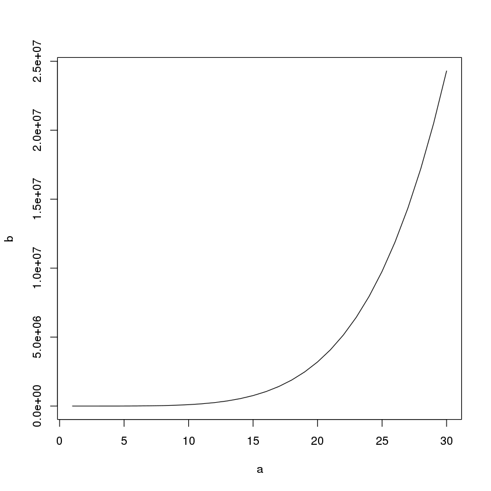

```r
a <- 1:30
 b <- a^5
 plot(a,b, type = "l") # definiu tipo linha
```

Exemplo de gráfico simples com atribuição de pontos em coordenadas cartesianas

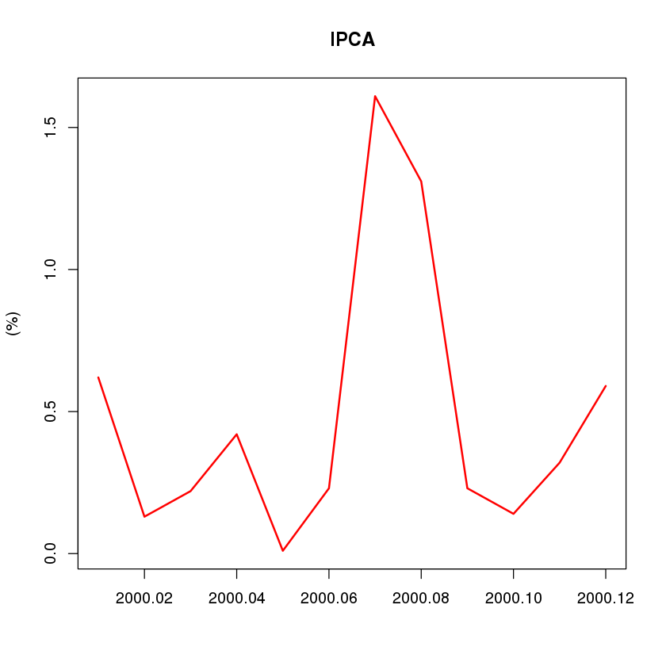

```r
plot(ipca[1:12,], xlab='', ylab='(%)', type='l', col='red', main='IPCA', lwd=2, lty=1)
#Exemplo de gráfico simples para a variável IPCA.
```

Os gráficos gerados podem ser salvos imediatamente a sua criação. Existem vários formatos em que o R pode salvar essas imagens. Alguns deles são: JPEG, BMP, PDF, TIFF, PNG. No exemplo a seguir será utilizando o formato PNG, contudo a sintaxe para qualquer formato é a mesma.

```r
png(file="Exemplo/plot.png") #onde plot refere-se ao nome da imagem
plot(a,b)   #grafico que estamos salvando
dev.off() #fecha a janela automaticamente
```

**png:** 2

```r
x = c(1,2,3,4,5,6)
y = c(34,48,65,73,82,90)
Z = data.frame(x,y)
#attach(Z)
png(file = "Exemplo/sc1.png")
plot(Z$x,Z$y)
dev.off()
```

**png:** 2

**Scatter plot**

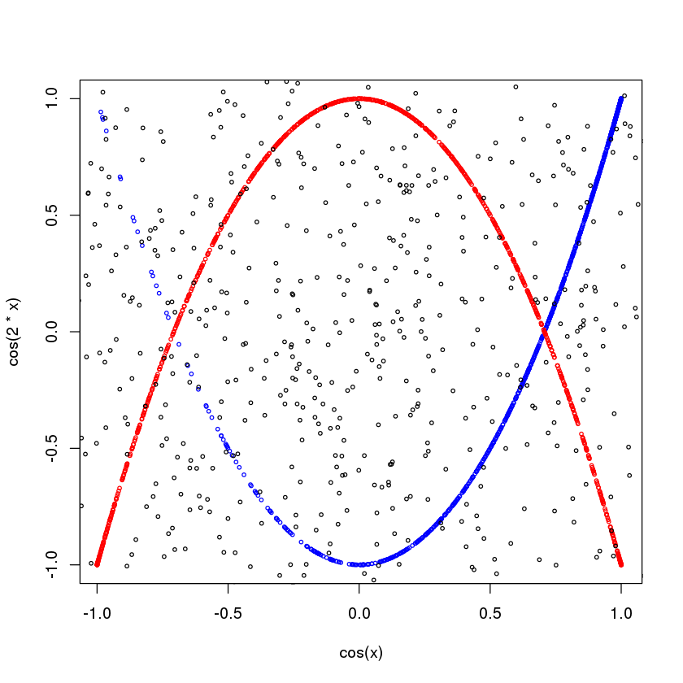

```r
x = rnorm(1000)
y = rnorm(1000)
plot( cos(x) ,cos(2*x) , cex = .5, col = "blue") +
points(sin(y),cos(2*y) , cex = .5, col = "red") +
points(x,y , cex = .5)
```

**Linhas**

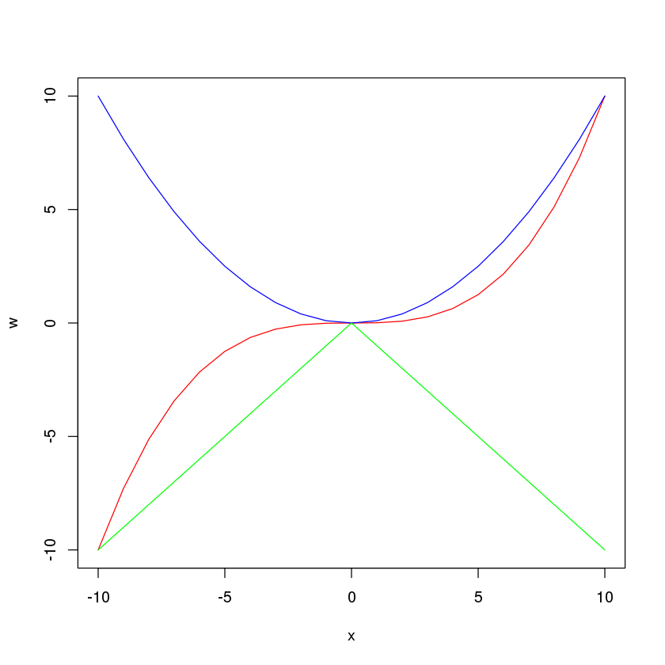

```r
x <- -10:10; y <- (x^2)/10; w <- (x^3)/100; z <- -abs(x);
plot(x,w, type = "l", col ="red")+
lines(x,y, col="blue")+
lines(x,z, col='green')
```

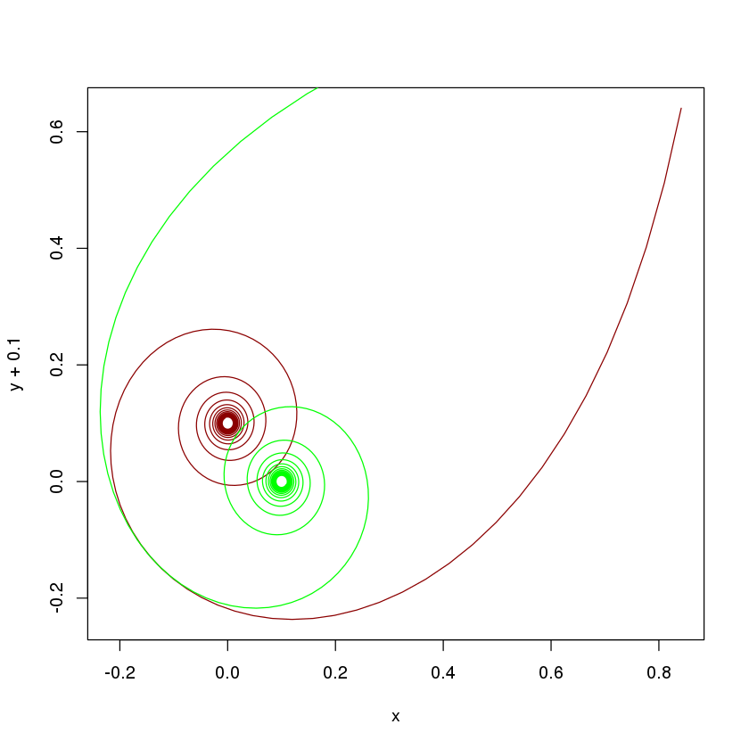

```r
t = 10:1000
x = sin(t/10)/(t/10)
y = cos(t/10)/(t/10)
plot(x,y+.1,type = "l", col = "dark red") +
lines(y+.1,x, col = "green")
```

**Histogramas**

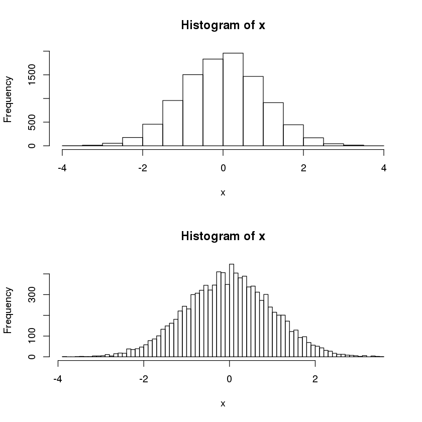

```r
x <- rnorm(1:10000)
par(mfrow=c(2,1))
hist (x, nclass = 20) # histograma com 20 classes
hist (x, nclass = 100) # histograma com 100 classes
```

**Barras**

A função `barplot()` gera gráfico de barras, onde cada barra representa a medida de cada elemento de um vetor, ou seja, as barras são proporcionais com a “dimensão” do elemento.

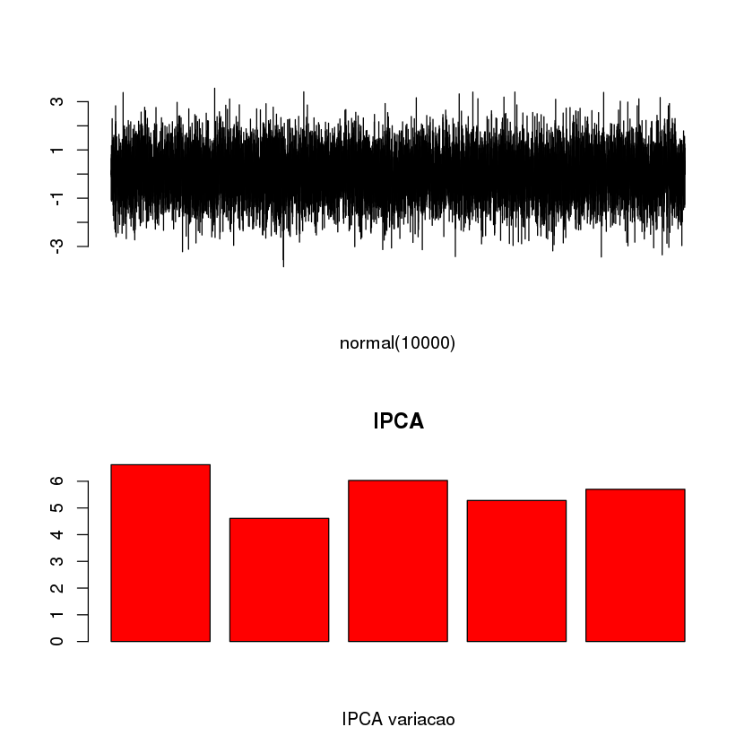

```r
# barplot(x, col=" ", legend.text=" ", xlab=" ",ylab=" ")
ipca2 <-c (6.62 ,4.61 ,6.03 ,5.28 , 5.70)
par(mfrow=c(2,1))
barplot(x, xlab="normal(10000)")
barplot(ipca2,xlab="IPCA variacao",col="red") + title("IPCA")
```

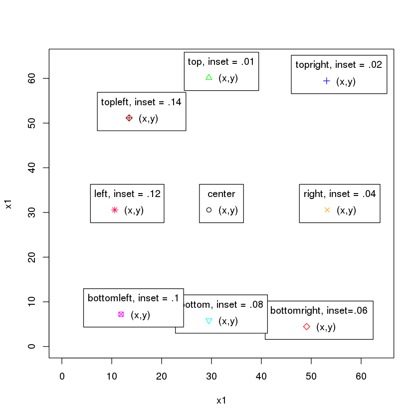

```r
x1 <- 0:64
plot(x1, x1, type= "n")
legend("center",      "(x,y)", pch = 1, title = "center")
legend("top",         "(x,y)", pch = 2, title = "top, inset = .01",       inset = .01, col="green")
legend("topright",    "(x,y)", pch = 3, title = "topright, inset = .02",  inset = .02, col="blue")
legend("right",       "(x,y)", pch = 4, title = "right, inset = .04",     inset = .04, col='orange')
legend("bottomright", "(x,y)", pch = 5, title = "bottomright, inset=.06", inset = .06, col='red')
legend("bottom",      "(x,y)", pch = 6, title = "bottom, inset = .08",    inset = .08, col="cyan")
legend("bottomleft",  "(x,y)", pch = 7, title = "bottomleft, inset = .1", inset = .1,  col="magenta")
legend("left",        "(x,y)", pch = 8, title = "left, inset = .12",      inset = .12, col="#FF004D")
legend("topleft",     "(x,y)", pch = 9, title = "topleft, inset = .14",   inset = .14, col="dark red")
```

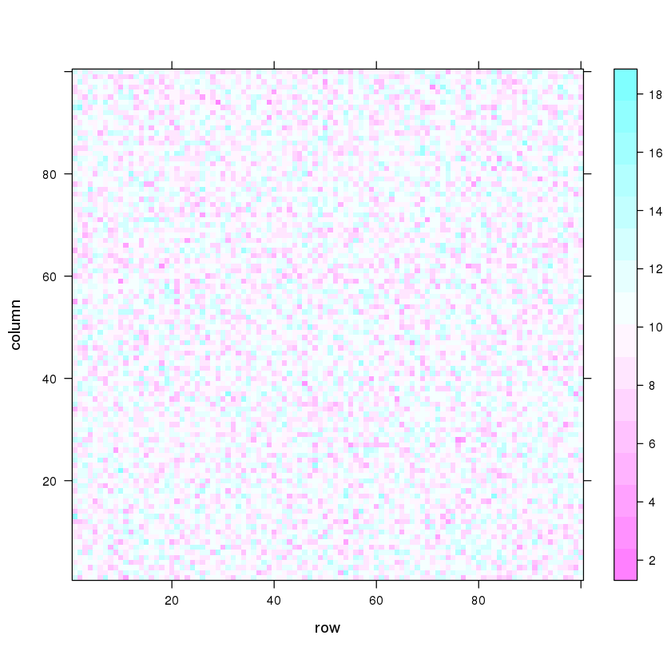

```r
library("lattice")

si = 100
## Example data
data=matrix(rnorm(si*si, 10, 2) , si , si)
# colnames(data)=letters[c(1:si)]
#rownames(data)=paste( rep("row",si) , c(1:si) , sep=" ")

## Try it out
#par(mar=c(3,4,2,2))
levelplot(t(data[c(nrow(data):1) , ]))
```